# Model Test

```r
#前処理
library(dlm)
library(dplyr)
par(mfrow=c(1,1))
query<-read.csv("toyota/daily.csv",sep="\t")
grp<-read.csv("toyota/grp.csv")
```

### 単純に日別視聴率で回帰

観測モデル

$$y_t=x^0_t\beta_0,_t + x^1_t\beta_1,_t + e_t ~~~~~e_t\sim N(0,\sigma^2) \\
=(x^0_t,x^1_t)(\beta_0,_t,\beta_1)^t + e_t \\
=H_t\beta_t + e_t$$

平滑化事前分布により上記のβを以下のようにモデル化する

$$\beta_{0,t} = \beta_{0,t-1}+v^0_t, ~~~~v^0_t\sim N(0,\tau^2_0) \\
\beta_{1,t} = \beta_{1,t-1}+v^1_t, ~~~~v^1_t\sim N(0,\tau^2_1) \\$$

上記をベクトル表現すると、以下システムモデルの式が得られる。

$$\beta_t=F_t\beta_{t-1}+G_t v_t \\
\left[
\begin{array}{c}
\beta_{0,t} \\\beta_{1,t}
\end{array}
\right]
=
\left[
\begin{array}{cc}
1&0 \\0&1
\end{array}
\right]
\left[
\begin{array}{c}
\beta_{0,t-1} \\\beta_{1,t-1}
\end{array}
\right]
+
\left[
\begin{array}{cc}
1&0 \\0&1
\end{array}
\right]
\left[
\begin{array}{c}
v^0_t \\v^1_t
\end{array}
\right]$$

```r
# 検索数前処理
q <- query %>%
  dplyr::select(StartDate,Queries) %>%
  dplyr::group_by(date=as.Date(StartDate)) %>%
  dplyr::summarise(query = sum(Queries))
# 視聴数を単純に日別集計
g<- grp %>%
  dplyr::select(date,person) %>%
  dplyr::group_by(date=as.Date(date)) %>%
  dplyr::summarise(grp = sum(person))
g[is.na(g)]<-0
#視聴率と検索を結合
d <- dplyr::inner_join(q,g,by="date")
y<-log(d$query)
x<-log(d$grp) #CM視聴数＝説明変数
#dVは観測モデルの分散。dWはシステムモデルの切片と回帰係数の分散。ここを固定にすると時変しなくなる
build.1 <- function(params){
  dlmModReg(x, dV = exp(params[1]), dW = exp(params[2:3]))
}
fit.1 <- dlmMLE(y,rep(0,3),build.1,hessian=T,control = list(maxit = 1000,trace=1))
-2*fit.1$value+2*4
```

```
[1] 1147.302
```

もっとも単純なモデル。fit.1$valueは最大対数尤度。

$$AIC=-2\times対数尤度+2\timesパラメータ数$$

```r
#dVは観測モデルの分散。dWはシステムモデルの切片と回帰係数の分散。ここを固定にすると時変しなくなる
build.1 <- function(params){
  dlmModReg(x, dV = exp(params[1]), dW = exp(params[2:3]))
}
fit.1 <- dlmMLE(y,rep(0,3),build.1,hessian=T,control = list(maxit = 1000,trace=1))
-2*fit.1$value+2*4
```

```
[1] 1147.302
```

exp(fit1.$par)は推定された分散、sqrtして標準偏差求める

```r
sqrt(exp(fit.1$par))
```

```
[1] 6.861689e-02 6.815585e-02 4.482710e-06
```

```r
dlmplotfit(fit.1)
```

```
 エラー:  関数 "dlmplotfit" を見つけることができませんでした
```

左から順番に、観測誤差、過程誤差1、2の標準偏差。

```r
mod1 <- build.1(fit.1$par) #さらに推定された値をパラメータとして入力
mod1$JFF
```

```
     [,1] [,2]
[1,]    0    1
```

```r
mod1$FF
```

```
     [,1] [,2]
[1,]    1    1
```

```r
head(mod1$X)
```

```
         [,1]
[1,] 3.552487
[2,] 3.923952
[3,] 4.084294
[4,] 3.161247
[5,] 2.965273
[6,] 2.140066
```

JFF：「説明変数がどこに入るか」を表した行列。2列目が「1」なので、FFの2列目に1番目の説明変数が入る。  
X：説明変数。1行目がFFに入る。時間tにおいて、Xのt行目の値が入る。

[figure not shown]

### Networkごとに視聴率集計

観測モデル

$$\begin{equation}
y_t=x^0_t\beta_{0,t} + x^1_t\beta_{1,t} + ... + x^5_t\beta_{0,t} + e_t ~~~~~e_t\sim N(0,\sigma^2) \\
=(x^0_t,x^1_t,x^2_t,x^3_t,x^5_t)(\beta_{0,t},\beta_{1,t},\beta_{2,t},\beta_{3,t},\beta_{4,t},\beta_{5,t})^t + e_t \\
=H_t\beta_t + e_t
\end{equation}$$

平滑化事前分布により上記のβを以下のようにモデル化する

$$\beta_{0,t} = \beta_{0,t-1}+v^0_t, ~~~~v^0_t\sim N(0,\tau^2_0) \\
\beta_{1,t} = \beta_{1,t-1}+v^1_t, ~~~~v^1_t\sim N(0,\tau^2_1) \\
\beta_{2,t} = \beta_{2,t-1}+v^2_t, ~~~~v^2_t\sim N(0,\tau^2_2) \\
\beta_{3,t} = \beta_{3,t-1}+v^3_t, ~~~~v^3_t\sim N(0,\tau^2_3) \\
\beta_{4,t} = \beta_{4,t-1}+v^4_t, ~~~~v^4_t\sim N(0,\tau^2_4) \\
\beta_{5,t} = \beta_{5,t-1}+v^5_t, ~~~~v^5_t\sim N(0,\tau^2_5) \\$$
上記をベクトル表現すると、以下システムモデルの式が得られる。
$$\beta_t=F_t\beta_{t-1}+G_t v_t \\
\left[
\begin{array}{c}
\beta_{0,t} \\\beta_{1,t}\\...\\\beta_{5,t}
\end{array}
\right]
=
\left[
\begin{array}{cccc}
1&0&0&0&0 \\0&1&0&0&0\\0&0&1&0&0\\0&0&0&1&0\\0&0&0&0&1
\end{array}
\right]
\left[
\begin{array}{c}
\beta_{0,t-1} \\\beta_{1,t-1}\\...\\\beta_{5,t-1}
\end{array}
\right]
+
\left[
\begin{array}{ccccc}
1&0&0&0&0 \\0&1&0&0&0\\0&0&1&0&0\\0&0&0&1&0\\0&0&0&0&1
\end{array}
\right]
\left[
\begin{array}{c}
v^0_t \\v^1_t\\...\\v^5_t
\end{array}
\right]$$

```r
g<- grp %>%
  dplyr::select(date,network,person) %>%
  dplyr::group_by(date=as.Date(date),network) %>%
  dplyr::summarise(grp = sum(person)) %>%
  tidyr::spread(key = network, value = grp)
g[is.na(g)]<-0
#視聴率と検索を結合
d <- dplyr::inner_join(q,g,by="date")
y<-log(d$query)
x1<-sqrt(d$CX)
x2<-sqrt(d$EX)
x3<-sqrt(d$NTV)
x4<-sqrt(d$TBS)
x5<-sqrt(d$TX)
vars<-cbind(x1,x2,x3,x4,x5)
build.2 <- function(params){
  # exp(param[1])の対数変換した空間で線形探索（山登り方で負の値もとらせるため）
  # システムノイズのxごとの傾き5個＋切片＋観測ノイズの分散でパラメータ数全部で7個
  dlmModReg(vars,dV = exp(params[1]), dW = exp(params[2:7]))
}
#デフォルトでマイナスから＋無限大に設定されてるのでupper,lowerで各パラメータの上限指定
#log(0.000001),log(0.1)を指定するとエラーになるので直接-13,-2を指定
fit.2<-dlmMLE(y,rep(0,7),build.2
              ,lower = c(rep(-30,7))
              ,upper = c(rep(0,7)) ,hessian=T
              ,control = list(maxit = 1000,trace=1))
fit.2$convergence
```

```
[1] 0
```

```r
# Estimated variance
fit.2$par
```

```
[1]  -5.311131  -5.441081 -29.533905 -30.000000 -30.000000 -29.513074
[7] -20.554473
```

```r
exp(fit.2$par)
```

```
[1] 4.936343e-03 4.334797e-03 1.491379e-13 9.357623e-14 9.357623e-14
[6] 1.522772e-13 1.183875e-09
```

```r
fit.2$value
```

```
[1] -517.5313
```

```r
# Build model using the estimated var
mod2 <- build.2(fit.2$par)
filt2<-dlmFilter(y,mod2)
smooth2 <- dlmSmooth(filt2)
par(mfrow=c(2,3))
a0<-dropFirst(smooth2$s[,1])
a1<-dropFirst(smooth2$s[,2]) #CX
a2<-dropFirst(smooth2$s[,3]) #EX
a3<-dropFirst(smooth2$s[,4]) #NTV
a4<-dropFirst(smooth2$s[,5]) #TBS
a5<-dropFirst(smooth2$s[,6]) #TX
estimatedLevel <- a0+x1*a1+x2*a2+x3*a3+x4*a4+x5*a5
plot(y, type="l", col=8, ylab="", main="Filtered Result")
lines(filt2$f,type="l",col=2)
```

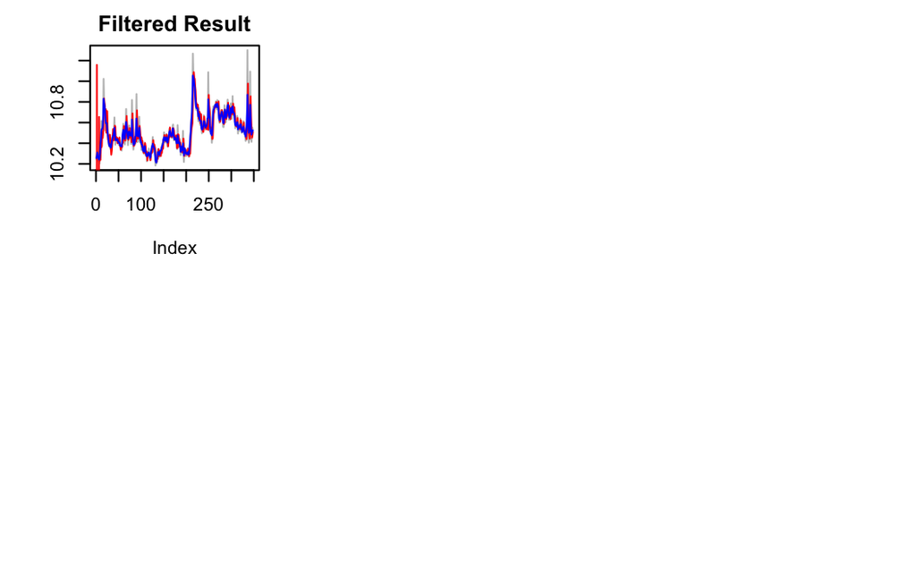

```r
lines(estimatedLevel,type="l",col=4)
par(mfrow=c(2,3))
```

```r
plot(a1,type="l",xlab="days",ylab="beta_0" )
plot(a2,type="l",xlab="days",ylab="beta_1")
```

```r
plot(a3,type="l",xlab="days",ylab="beta_2")
plot(a4,type="l",xlab="days",ylab="beta_3")
```

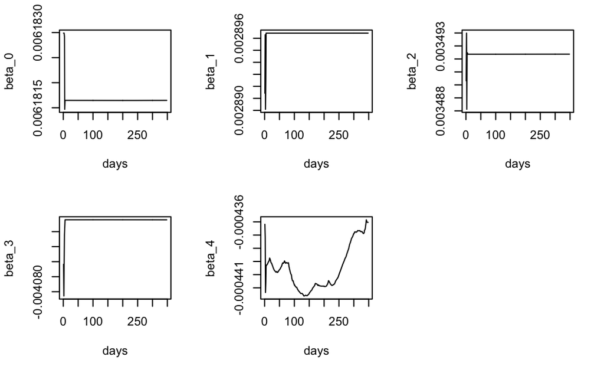

```r
plot(a5,type="l",xlab="days",ylab="beta_4")
plot(a6,type="l",xlab="days",ylab="beta_5")
```

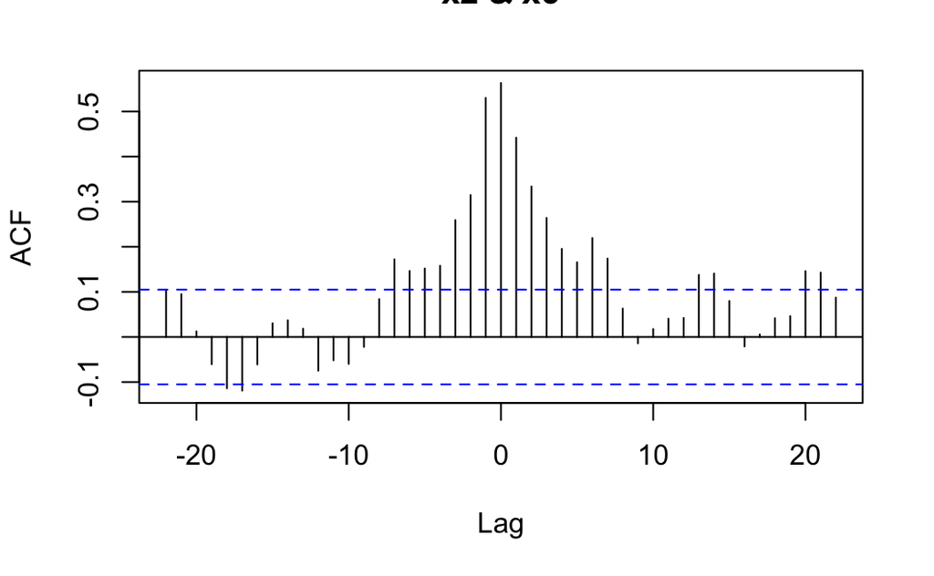

```r
#相互相関をみるとLag0,1で0.6近くあり極めて相関が高い
ccf(x2,x3)
```

## 時間帯ごとのモデル

```r
grp$time<-gsub("(10|11|12|13|14)", "Noon", grp$time)
grp$time<-gsub("(15|16|17|18)", "Evening", grp$time)
grp$time<-gsub("(19|20|21|22|23)", "Prime", grp$time)
grp$time<-gsub("(24|25|26|27|28|[1-5])", "Midnight", grp$time)
grp$time<-gsub("([6-9])", "Morning", grp$time)
g<- grp %>%
  dplyr::select(date,time,person) %>%
  dplyr::group_by(date=as.Date(date),time) %>%
  dplyr::summarise(grp = sum(person)) %>%
  tidyr::spread(key = time, value = grp)
g[is.na(g)]<-0
#視聴率と検索を結合
d <- dplyr::inner_join(q,g,by="date")
y<-log(d$query)
x1<-log(d$Morning+1)
x2<-log(d$Noon+1)
x3<-log(d$Evening+1)
x4<-log(d$Prime+1)
x5<-log(d$Midnight+1)
vars<-cbind(x1,x2,x3,x4,x5)
build.3 <- function(params){
  # exp(param[1])の対数変換した空間で線形探索（山登り方で負の値もとらせるため）
  mod1<- dlmModReg(vars,dV = exp(params[1]), dW = exp(params[2:7]))
  return(mod1)
}
#デフォルトでマイナスから＋無限大に設定されてるのでupper,lowerで各パラメータの上限指定
#log(0.000001),log(0.1)を指定するとエラーになるので直接-13.8,-2.3を指定
fit.3<-dlmMLE(y,rep(0,7),build.3,hessian=T
              ,control = list(maxit = 1000,trace=1))
fit.3$convergence
```

```
[1] 0
```

```r
fit.3$par
```

```
[1]  -5.413816  -5.341704 -25.447740 -28.823533 -25.839943 -29.704977
[7] -24.002753
```

```r
exp(fit.3$par)
```

```
[1] 4.454607e-03 4.787707e-03 8.875379e-12 3.034580e-13 5.995912e-12
[6] 1.256876e-13 3.764755e-11
```

```r
fit.3$value
```

```
[1] -522.2591
```

Build model using the estimated var

```r
mod3 <- build.3(fit.3$par)
filt3<-dlmFilter(y,mod3)
smooth3 <- dlmSmooth(filt3)
a1<-dropFirst(smooth3$s[,1])
a2<-dropFirst(smooth3$s[,2]) #Morning
a3<-dropFirst(smooth3$s[,3]) #Noon
a4<-dropFirst(smooth3$s[,4]) #Evening
a5<-dropFirst(smooth3$s[,5]) #Prime
a6<-dropFirst(smooth3$s[,6]) #Midnight
estimatedLevel <- a0+x1*a1+x2*a2+x3*a3+x4*a4+x5*a5
plot(y, type="l", col=8, ylab="", main="Filtered Result")
lines(filt3$f,type="l",col=2)
```

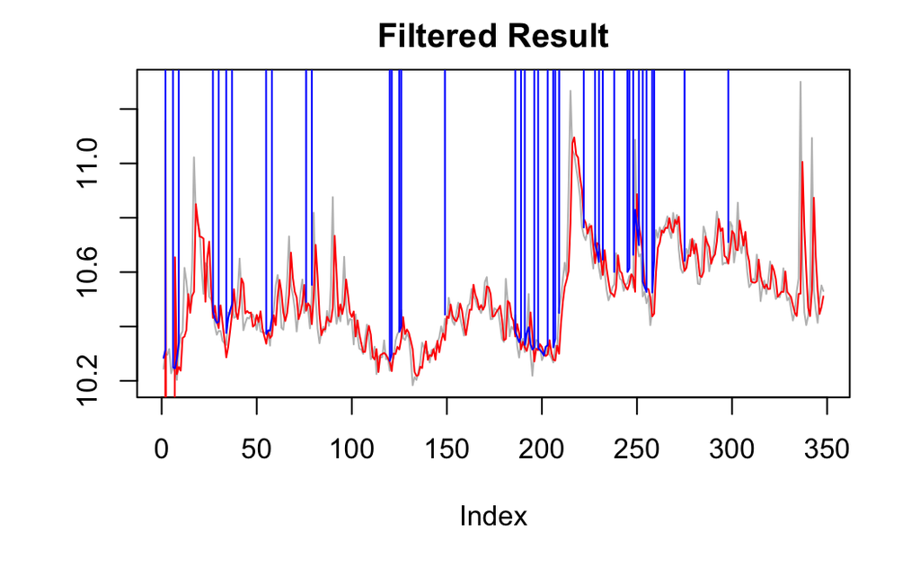

```r
lines(estimatedLevel,type="l",col=4)
par(mfrow=c(2,3))
```

```r
plot(a1,type="l",xlab="days",ylab="beta_0" )
plot(a2,type="l",xlab="days",ylab="beta_1")
```

```r
plot(a3,type="l",xlab="days",ylab="beta_2")
plot(a4,type="l",xlab="days",ylab="beta_3")
```

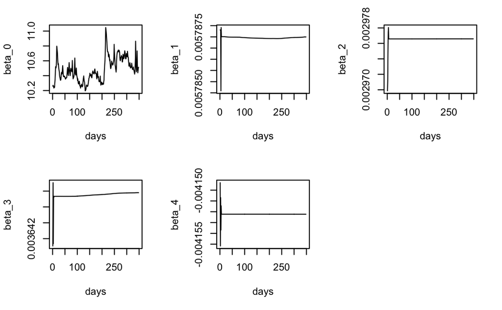

```r
plot(a5,type="l",xlab="days",ylab="beta_4")
plot(a6,type="l",xlab="days",ylab="beta_5")
```

## Genreごとに集計

```r
grp$Genre<-gsub("(Cooking|Travel|Trava|Shopping|Local)", "Informative", grp$Genre)
grp$Genre<-gsub("(Movie|Anime)", "Drama", grp$Genre)
grp$Genre<-gsub("(Music|Documentary|undefined|'')", "Variety", grp$Genre)
g<- grp %>%
  dplyr::select(date,Genre,person) %>%
  dplyr::group_by(date=as.Date(date),genre=Genre) %>%
  dplyr::summarise(grp = sum(person)) %>%
  tidyr::spread(key = genre, value = grp)
g[is.na(g)]<-0
#視聴率と検索を結合
d <- dplyr::inner_join(q,g,by="date")
y<-log(d$query)
x1<-log(d$Drama+1)
x2<-log(d$Informative+1)
x3<-log(d$News+1)
x4<-log(d$Sports+1)
x5<-log(d$Variety+1)
vars<-cbind(x1,x2,x3,x4,x5)
build.4 <- function(params){
  # exp(param[1])の対数変換した空間で線形探索（山登り方で負の値もとらせるため）
  dlmModReg(vars,dV = exp(params[1]), dW = exp(params[2:7]))
}
fit.4<-dlmMLE(y,parm=rep(0,7),build=build.4
              ,lower = c(rep(-13.8,7))
              ,upper = c(rep(-2.3,7)),hessian=T
              ,control = list(maxit = 1000,trace=1))
fit.4$convergence
```

```
[1] 0
```

```r
fit.4$par
```

```
[1]  -5.389007  -5.425778 -13.800000 -13.800000 -12.306219 -13.800000
[7] -13.800000
```

```r
exp(fit.4$par)
```

```
[1] 4.566504e-03 4.401640e-03 1.015631e-06 1.015631e-06 4.523525e-06
[6] 1.015631e-06 1.015631e-06
```

```r
fit.4$value
```

```
[1] -520.8983
```

```r
# Build model using the estimated var
mod4 <- build.4(fit.4$par)
filt4<-dlmFilter(y,mod4)
smooth4 <- dlmSmooth(filt4)
a1<-dropFirst(smooth4$s[,1])
a2<-dropFirst(smooth4$s[,2]) #Morning
a3<-dropFirst(smooth4$s[,3]) #Noon
a4<-dropFirst(smooth4$s[,4]) #Evening
a5<-dropFirst(smooth4$s[,5]) #Prime
a6<-dropFirst(smooth4$s[,6]) #Midnight
estimatedLevel <- a1+x*(a2+a3+a4+a5+a6) #どうやって記述すればいい？
plot(y, type="l", col=8, ylab="", main="Filtered Result")
lines(filt4$f,type="l",col=2)
```

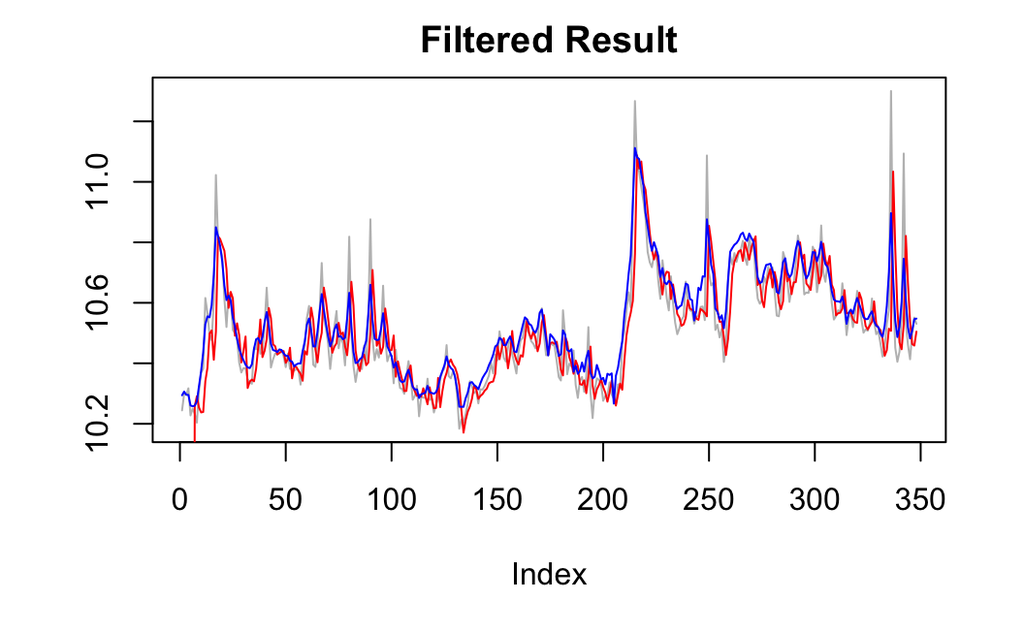

```r
lines(estimatedLevel,type="l",col=4)
```

```r
-2*fit.1$value+2*3 #単純集計
```

```
[1] 1145.302
```

Mazda(時間帯) [1] 1209.443 [1] 1118.573 [1] 567.2308 [1] 1132.517

Suzuki(時間帯) [1] 816.6708 [1] 745.4678 [1] 737.8359 [1] 741.6222

Nissan(局) [1] 1026.343 [1] 935.1094 [1] 940.6592 [1] 961.1829

Honda(局) [1] 1396.388 [1] 1306.174 [1] 1319.015 [1] 1318.604

Toyota(局) [1] 1145.302 [1] 1049.063 [1] 1058.518 [1] 1055.797